# Examples for Krijn

Joe Brew

October 4, 2016

Krijn, I’ve addressed some of your points. Specifically, I’m having trouble understanding Part B, number 3: “Select ‘from’ and ‘to’ values (e.g. 0,4 to 0,75).”

What do these values refer to? X (human blood index), Y (place of biting), Z (time), or something else?

I cannot draw a lines onto the chart without a bit more clarification on this…

# Part A

We just want to have a 3D box (image) with: 1) x-axis: Human Blood Index (values from 0 to 1) 2) y-axis: Place of biting (values from 0 to 1) 3) z-axis: time of biting from 12pm to 12pm (so starting in the afternoon)

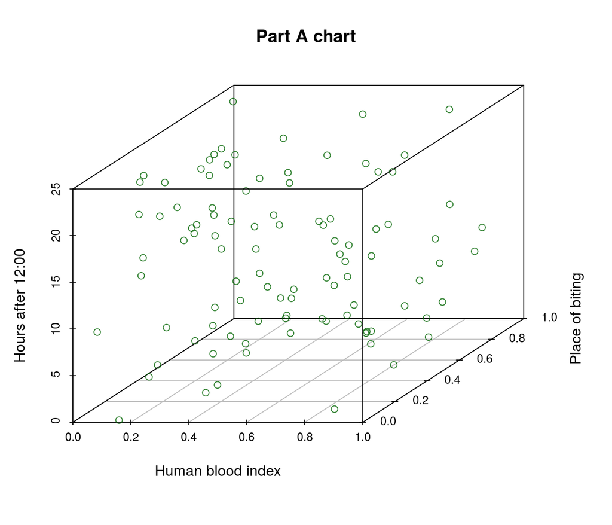

```r
# Create a dataframe of random points to plot
x <- sample(seq(0, 1, length = 10000), 100)
y <- sample(seq(0, 1, length = 10000), 100)
z <- seq(0, 24, length = 100)
df <- data.frame(x, y, z)
scatterplot3d(x = df$x,
              y = df$y,
              z = df$z,
              xlab = 'Human blood index',
              ylab = 'Place of biting',
              zlab = 'Hours after 12:00',
              pch = 01,
              color = adjustcolor('darkgreen', alpha.f = 0.8),
              main = 'Part A chart')
```

# Part B

For each item (whether it a mosquito, or a trap, etc), we would like to: 1) Give it a name to appear in the legend 2) Give it a unique color 3) Choose a shape (square or ball, which could be oval) And select ‘from’ and ‘to’ values (e.g. 0,4 to 0,75) for 4) Human Blood Index (values from 0 to 1) 5) Place of biting (values from 0 to 1) 6)Time of biting from 12pm to 12pm (so starting in the afternoon)

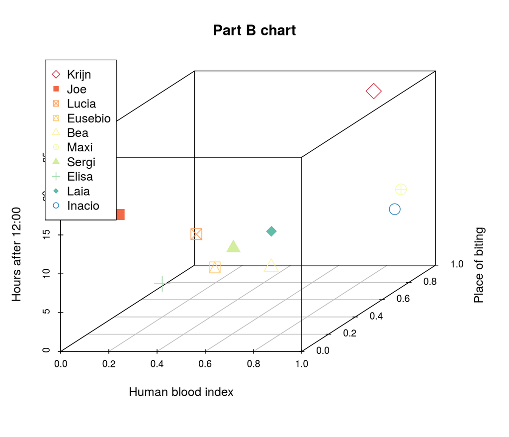

```r
# Make our dataframe smaller (only 10 points)
df <- df[sample(1:100, 10),]

# Add more information to our dataframe
df$name <- c('Krijn',
             'Joe',
             'Lucia',
             'Eusebio',
             'Bea',
             'Maxi',
             'Sergi',
             'Elisa',
             'Laia',
             'Inacio')
df$color <-
  colorRampPalette(brewer.pal(9, 'Spectral'))(nrow(df))
df$shape <- sample(1:20, nrow(df))

scatterplot3d(x = df$x,
              y = df$y,
              z = df$z,
              xlab = 'Human blood index',
              ylab = 'Place of biting',
              zlab = 'Hours after 12:00',
              cex.symbols = 2,
              pch = df$shape,
              color = adjustcolor(df$color, alpha.f = 0.99),
              main = 'Part B chart')
legend('topleft',
       pch = df$shape,
       col = df$color,
       legend = df$name)
```

# Part C

Repeat part B to show multiple items in the same graph.